# Statistical Evaluation : Sample Size and Power Calculations for Tests Comparing Proportions in Clinical Research

```r
##################################
# Conducting a pairwise comparison
# between Treatments A and C
##################################

##################################
# Computing the range of samples sizes based on different levels of Type II errors
##################################
beta_1=beta[1]
(n_Beta30=(p_AF*(1-p_AF)+p_CR*(1-p_CR))*
    ((qnorm(1-alpha/2/tau)+qnorm(1-beta_1))/(p_AF-p_CR))^2)
```

```
## [1] 12.605077 11.389522 10.292767  9.299112  8.395418  7.570617
```

```r
ceiling(n_Beta30)
```

```
## [1] 13 12 11 10  9  8
```

```r
z_Beta30=(p_AF-p_CR)/sqrt(p_AF*(1-p_AF)/n_Beta30+p_CR*(1-p_CR)/n_Beta30)
(Power_Beta30=pnorm(z_Beta30-qnorm(1-alpha/2/tau))+pnorm(-z_Beta30-qnorm(1-alpha/2/tau)))
```

```
## [1] 0.7000001 0.7000001 0.7000001 0.7000001 0.7000001 0.7000001
```

```r
beta_2=beta[2]
(n_Beta20=(p_AF*(1-p_AF)+p_CR*(1-p_CR))*
    ((qnorm(1-alpha/2/tau)+qnorm(1-beta_2))/(p_AF-p_CR))^2)
```

```
## [1] 15.494289 14.000117 12.651975 11.430563 10.319733  9.305879
```

```r
ceiling(n_Beta20)
```

```
## [1] 16 15 13 12 11 10
```

```r
z_Beta20=(p_AF-p_CR)/sqrt(p_AF*(1-p_AF)/n_Beta20+p_CR*(1-p_CR)/n_Beta20)
(Power_Beta20=pnorm(z_Beta20-qnorm(1-alpha/2/tau))+pnorm(-z_Beta20-qnorm(1-alpha/2/tau)))
```

```
## [1] 0.8 0.8 0.8 0.8 0.8 0.8
```

```r
beta_3=beta[3]
(n_Beta10=(p_AF*(1-p_AF)+p_CR*(1-p_CR))*
    ((qnorm(1-alpha/2/tau)+qnorm(1-beta_3))/(p_AF-p_CR))^2)
```

```
## [1] 19.99411 18.06600 16.32633 14.75020 13.31677 12.00847
```

```r
ceiling(n_Beta10)
```

```
## [1] 20 19 17 15 14 13
```

```r
z_Beta10=(p_AF-p_CR)/sqrt(p_AF*(1-p_AF)/n_Beta10+p_CR*(1-p_CR)/n_Beta10)
(Power_Beta10=pnorm(z_Beta10-qnorm(1-alpha/2/tau))+pnorm(-z_Beta10-qnorm(1-alpha/2/tau)))
```

```
## [1] 0.9 0.9 0.9 0.9 0.9 0.9
```

```r
MultipleSampleDesign.AC.Equality <- as.data.frame(cbind(p_AF,p_CR,n_Beta30,n_Beta20,n_Beta10))
names(MultipleSampleDesign.AC.Equality) <- c("Treatment_A.Response.Rate",
                                             "Treatment_B.Response.Rate",
                                             "Power=70%",
                                             "Power=80%",
                                             "Power=90%")

##################################
# Restructuring the data
##################################
MultipleSampleDesign.AC.Equality.Reshaped <- gather(MultipleSampleDesign.AC.Equality,
                                            "Power=70%","Power=80%","Power=90%",
                                            key="Power",
                                            value="Sample.Size")
MultipleSampleDesign.AC.Equality.Reshaped$Label <- rep("MSDOWAP_AC_EQUALITY",nrow(MultipleSampleDesign.AC.Equality.Reshaped))

MultipleSampleDesign.AC.Equality.Reshaped
```

```
##    Treatment_A.Response.Rate Treatment_B.Response.Rate     Power Sample.Size
## 1                        0.2                      0.70 Power=70%   12.605077
## 2                        0.2                      0.72 Power=70%   11.389522
## 3                        0.2                      0.74 Power=70%   10.292767
## 4                        0.2                      0.76 Power=70%    9.299112
## 5                        0.2                      0.78 Power=70%    8.395418
## 6                        0.2                      0.80 Power=70%    7.570617
## 7                        0.2                      0.70 Power=80%   15.494289
## 8                        0.2                      0.72 Power=80%   14.000117
## 9                        0.2                      0.74 Power=80%   12.651975
## 10                       0.2                      0.76 Power=80%   11.430563
## 11                       0.2                      0.78 Power=80%   10.319733
## 12                       0.2                      0.80 Power=80%    9.305879
## 13                       0.2                      0.70 Power=90%   19.994106
## 14                       0.2                      0.72 Power=90%   18.066000
```

[output cut: 23 more lines]

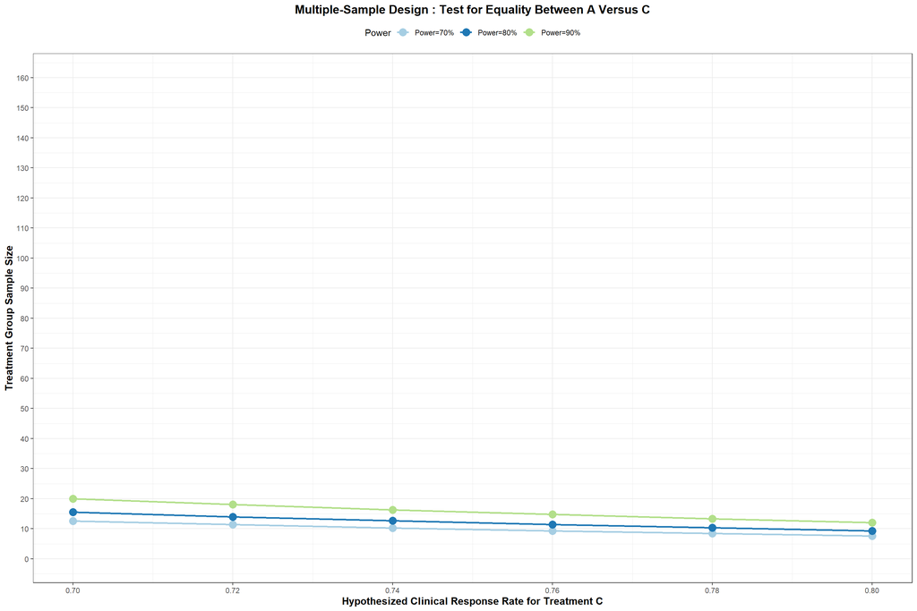

```r
##################################
# Plotting the sample sizes and power curves
##################################
(MultipleSampleDesign.AC.Equality.PowerAnalysis <-    ggplot(MultipleSampleDesign.AC.Equality.Reshaped,
                                                      aes(x=Treatment_B.Response.Rate,
                                                          y=Sample.Size,
                                                          color=Power)) +
   geom_line(size=1)+
   geom_point(size=4)+
   theme_bw() +
   scale_color_brewer(palette="Paired") +
   scale_x_continuous(name="Hypothesized Clinical Response Rate for Treatment C",
                      limits=c(0.70,0.80),
                      breaks=seq(0.70,0.80,by=0.02)) +
  scale_y_continuous(name="Treatment Group Sample Size",
                     limits=c(0,160),
                     breaks=seq(0,160,by=10)) +
  theme(axis.title.x=element_text(color="black",face="bold",size=12),
        legend.position="top",
        axis.title.y=element_text(color="black",face="bold",size=12),
        plot.title=element_text(color="black",size=14,face="bold",hjust=0.50)) +
  ggtitle("Multiple-Sample Design : Test for Equality Between A Versus C"))
```

```r
##################################
# Conducting a pairwise comparison
# between Treatments B and C
##################################

##################################
# Computing the range of samples sizes based on different levels of Type II errors
##################################
beta_1=beta[1]
(n_Beta30=(p_BF*(1-p_BF)+p_CR*(1-p_CR))*
    ((qnorm(1-alpha/2/tau)+qnorm(1-beta_1))/(p_BF-p_CR))^2)
```

```
## [1] 97.94485 79.46801 65.41486 54.47820 45.80030 38.79941
```

```r
ceiling(n_Beta30)
```

```
## [1] 98 80 66 55 46 39
```

```r
z_Beta30=(p_BF-p_CR)/sqrt(p_BF*(1-p_BF)/n_Beta30+p_CR*(1-p_CR)/n_Beta30)
(Power_Beta30=pnorm(z_Beta30-qnorm(1-alpha/2/tau))+pnorm(-z_Beta30-qnorm(1-alpha/2/tau)))
```

```
## [1] 0.7000001 0.7000001 0.7000001 0.7000001 0.7000001 0.7000001
```

```r
beta_2=beta[2]
(n_Beta20=(p_BF*(1-p_BF)+p_CR*(1-p_CR))*
    ((qnorm(1-alpha/2/tau)+qnorm(1-beta_2))/(p_BF-p_CR))^2)
```

```
## [1] 120.39481  97.68289  80.40861  66.96516  56.29819  47.69263
```

```r
ceiling(n_Beta20)
```

```
## [1] 121  98  81  67  57  48
```

```r
z_Beta20=(p_BF-p_CR)/sqrt(p_BF*(1-p_BF)/n_Beta20+p_CR*(1-p_CR)/n_Beta20)
(Power_Beta20=pnorm(z_Beta20-qnorm(1-alpha/2/tau))+pnorm(-z_Beta20-qnorm(1-alpha/2/tau)))
```

```
## [1] 0.8 0.8 0.8 0.8 0.8 0.8
```

```r
beta_3=beta[3]
(n_Beta10=(p_BF*(1-p_BF)+p_CR*(1-p_CR))*
    ((qnorm(1-alpha/2/tau)+qnorm(1-beta_3))/(p_BF-p_CR))^2)
```

```
## [1] 155.35960 126.05174 103.76070  86.41303  72.64819  61.54342
```

```r
ceiling(n_Beta10)
```

```
## [1] 156 127 104  87  73  62
```

```r
z_Beta10=(p_BF-p_CR)/sqrt(p_BF*(1-p_BF)/n_Beta10+p_CR*(1-p_CR)/n_Beta10)
(Power_Beta10=pnorm(z_Beta10-qnorm(1-alpha/2/tau))+pnorm(-z_Beta10-qnorm(1-alpha/2/tau)))
```

```
## [1] 0.9 0.9 0.9 0.9 0.9 0.9
```

```r
MultipleSampleDesign.BC.Equality <- as.data.frame(cbind(p_BF,p_CR,n_Beta30,n_Beta20,n_Beta10))
names(MultipleSampleDesign.BC.Equality) <- c("Treatment_A.Response.Rate",
                                             "Treatment_B.Response.Rate",
                                             "Power=70%",
                                             "Power=80%",
                                             "Power=90%")

##################################
# Restructuring the data
##################################
MultipleSampleDesign.BC.Equality.Reshaped <- gather(MultipleSampleDesign.BC.Equality,
                                            "Power=70%","Power=80%","Power=90%",
                                            key="Power",
                                            value="Sample.Size")
MultipleSampleDesign.BC.Equality.Reshaped$Label <- rep("MSDOWAP_BC_EQUALITY",nrow(MultipleSampleDesign.BC.Equality.Reshaped))

MultipleSampleDesign.BC.Equality.Reshaped
```

```
##    Treatment_A.Response.Rate Treatment_B.Response.Rate     Power Sample.Size
## 1                        0.5                      0.70 Power=70%    97.94485
## 2                        0.5                      0.72 Power=70%    79.46801
## 3                        0.5                      0.74 Power=70%    65.41486
## 4                        0.5                      0.76 Power=70%    54.47820
## 5                        0.5                      0.78 Power=70%    45.80030
## 6                        0.5                      0.80 Power=70%    38.79941
## 7                        0.5                      0.70 Power=80%   120.39481
## 8                        0.5                      0.72 Power=80%    97.68289
## 9                        0.5                      0.74 Power=80%    80.40861
## 10                       0.5                      0.76 Power=80%    66.96516
## 11                       0.5                      0.78 Power=80%    56.29819
## 12                       0.5                      0.80 Power=80%    47.69263
## 13                       0.5                      0.70 Power=90%   155.35960
## 14                       0.5                      0.72 Power=90%   126.05174
```

[output cut: 23 more lines]

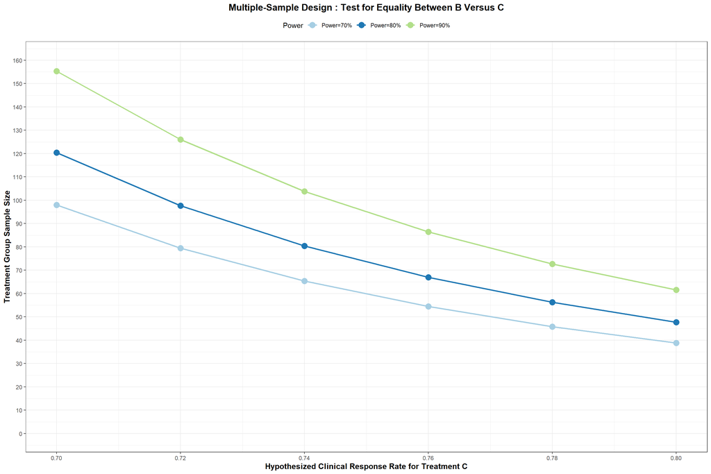

```r
##################################
# Plotting the sample sizes and power curves
##################################
(MultipleSampleDesign.BC.Equality.PowerAnalysis <-    ggplot(MultipleSampleDesign.BC.Equality.Reshaped,
                                                      aes(x=Treatment_B.Response.Rate,
                                                          y=Sample.Size,
                                                          color=Power)) +
   geom_line(size=1)+
   geom_point(size=4)+
   theme_bw() +
   scale_color_brewer(palette="Paired") +
   scale_x_continuous(name="Hypothesized Clinical Response Rate for Treatment C",
                      limits=c(0.70,0.80),
                      breaks=seq(0.70,0.80,by=0.02)) +
  scale_y_continuous(name="Treatment Group Sample Size",
                     limits=c(0,160),
                     breaks=seq(0,160,by=10)) +
  theme(axis.title.x=element_text(color="black",face="bold",size=12),
        legend.position="top",
        axis.title.y=element_text(color="black",face="bold",size=12),
        plot.title=element_text(color="black",size=14,face="bold",hjust=0.50)) +
  ggtitle("Multiple-Sample Design : Test for Equality Between B Versus C"))
```

### 1.4.2 Consolidated Evaluation

**[A]** The minimum sample size required for each treatment group in a Multiple-Sample Design One-Way ANOVA Pairwise study is dependent upon the following factors defined and hypothesized prior to the clinical research:  
**[A.1]** **Level of significance** (Alpha) : Lower value increases sample size  
**[A.2]** **Power of the test** (Beta) : Higher value increases sample size  
**[A.3]** **Epsilon** (Difference between the Treatment Response Rates) : Lower value increases sample size  
**[A.4]** **Tau** (Number of treatment groups) : Higher value increases sample size  
**[B]** Given the level of significance = 5%, number of treatments = 3 and a varying range of clinical response values across pairwise combinations of treatments, the sample size is determined as the maximum number obtained for all computations under each statistical power -  
**[B.1]** 70% power, sample size = 98  
**[B.2]** 80% power, sample size = 121  
**[B.3]** 90% power, sample size = 156

**Code Chunk | Output**

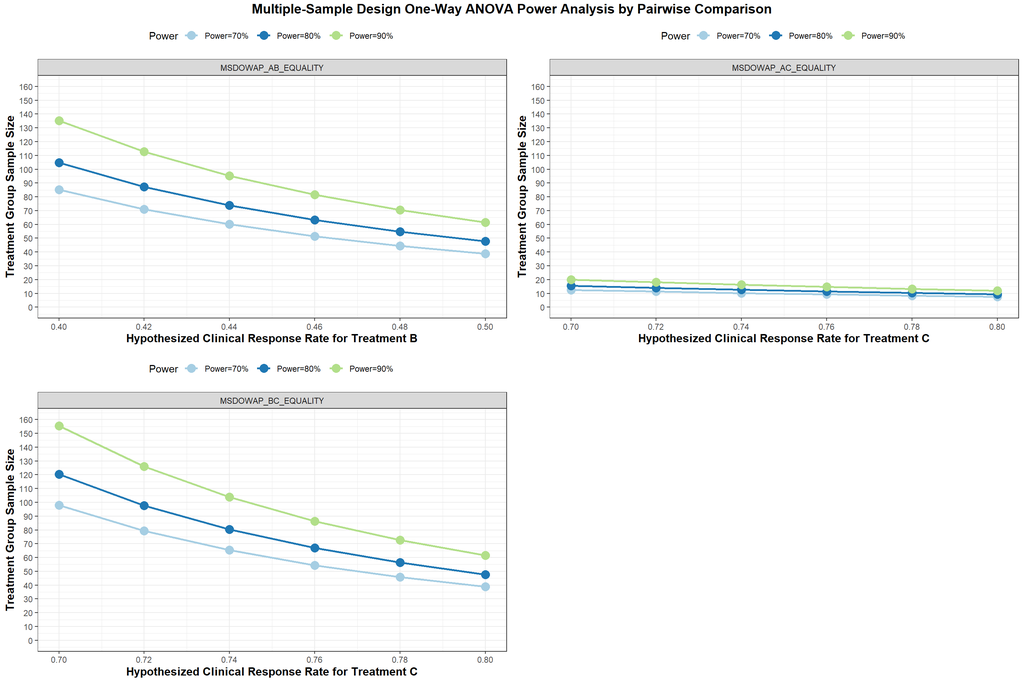

```r
##################################
# Consolidating the power analyses charts
##################################
MSDOWAP.AB.Equality.PowerAnalysis <- ggplot(MultipleSampleDesign.AB.Equality.Reshaped,
                                                      aes(x=Treatment_B.Response.Rate,
                                                          y=Sample.Size,
                                                          color=Power)) +
   geom_line(size=1)+
   geom_point(size=4)+
   theme_bw() +
   facet_grid(. ~ Label) +
   scale_color_brewer(palette="Paired") +
   scale_x_continuous(name="Hypothesized Clinical Response Rate for Treatment B",
                      limits=c(0.40,0.50),
                      breaks=seq(0.40,0.50,by=0.02)) +
  scale_y_continuous(name="Treatment Group Sample Size",
                     limits=c(0,160),
                     breaks=seq(0,160,by=10)) +
  theme(axis.title.x=element_text(color="black",face="bold",size=12),
        legend.position="top",
        axis.title.y=element_text(color="black",face="bold",size=12),
        plot.title=element_text(color="black",size=14,face="bold",hjust=0.50))

MSDOWAP.AC.Equality.PowerAnalysis <-  ggplot(MultipleSampleDesign.AC.Equality.Reshaped,
                                                      aes(x=Treatment_B.Response.Rate,
                                                          y=Sample.Size,
                                                          color=Power)) +
   geom_line(size=1)+
   geom_point(size=4)+
   theme_bw() +
   facet_grid(. ~ Label) +
   scale_color_brewer(palette="Paired") +
   scale_x_continuous(name="Hypothesized Clinical Response Rate for Treatment C",
                      limits=c(0.70,0.80),
                      breaks=seq(0.70,0.80,by=0.02)) +
  scale_y_continuous(name="Treatment Group Sample Size",
                     limits=c(0,160),
                     breaks=seq(0,160,by=10)) +
  theme(axis.title.x=element_text(color="black",face="bold",size=12),
        legend.position="top",
        axis.title.y=element_text(color="black",face="bold",size=12),
        plot.title=element_text(color="black",size=14,face="bold",hjust=0.50))

MSDOWAP.BC.Equality.PowerAnalysis <- ggplot(MultipleSampleDesign.BC.Equality.Reshaped,
                                                      aes(x=Treatment_B.Response.Rate,
                                                          y=Sample.Size,
                                                          color=Power)) +
   geom_line(size=1)+
   geom_point(size=4)+
   theme_bw() +
   facet_grid(. ~ Label) +
   scale_color_brewer(palette="Paired") +
   scale_x_continuous(name="Hypothesized Clinical Response Rate for Treatment C",
                      limits=c(0.70,0.80),
                      breaks=seq(0.70,0.80,by=0.02)) +
  scale_y_continuous(name="Treatment Group Sample Size",
                     limits=c(0,160),
                     breaks=seq(0,160,by=10)) +
  theme(axis.title.x=element_text(color="black",face="bold",size=12),
        legend.position="top",
        axis.title.y=element_text(color="black",face="bold",size=12),
        plot.title=element_text(color="black",size=14,face="bold",hjust=0.50))


MSDOWAP_PowerAnalysis <- ggarrange(MSDOWAP.AB.Equality.PowerAnalysis,
                                   MSDOWAP.AC.Equality.PowerAnalysis,
                                   MSDOWAP.BC.Equality.PowerAnalysis,
                                   ncol=2, nrow=2)

annotate_figure(MSDOWAP_PowerAnalysis,
                top = text_grob("Multiple-Sample Design One-Way ANOVA Power Analysis by Pairwise Comparison",
                                color = "black",
                                face = "bold",
                                size = 14))
```

# **2. Summary**

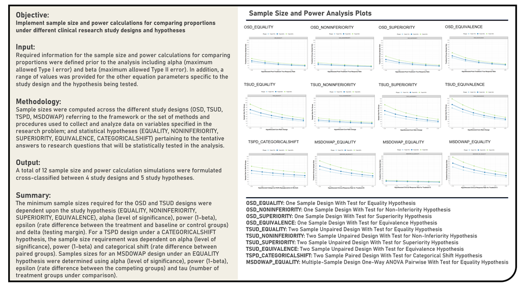

# **3. References**

**[Book]** [Sample Size Calculations in Clinical Research](https://www.taylorfrancis.com/books/mono/10.1201/9781315183084/sample-size-calculations-clinical-research-shein-chung-chow-jun-shao-hansheng-wang-yuliya-lokhnygina) by Shein-Chung Chow, Jun Shao, Hansheng Wang and Yuliya Lokhnygina  
**[Book]** [Clinical Trial Data Analysis Using R and SAS](https://www.taylorfrancis.com/books/mono/10.1201/9781315155104/clinical-trial-data-analysis-using-sas-ding-geng-din-chen-karl-peace-pinggao-zhang) by Ding-Geng Chen, Karl Peace and Pinggao Zhang  
**[Book]** [Design and Analysis of Experiments with R](https://www.taylorfrancis.com/books/mono/10.1201/b17883/design-analysis-experiments-john-lawson) by John Lawson  
**[Book]** [Design and Analysis of Experiments](https://link.springer.com/book/10.1007/978-3-319-52250-0) by Angela Dean , Daniel Voss and Danel Draguljić  
**[Book]** [Design and Analysis of Experiments](https://bcs.wiley.com/he-bcs/Books?action=index&bcsId=10790&itemId=1119320933) by Douglas Montgomery  
**[R Package]** [rstatix](https://mran.microsoft.com/web/packages/rstatix/index.html) by Alboukadel Kassambara  
**[R Package]** [car](https://cran.r-project.org/web/packages/car/vignettes/embedding.pdf) by John Fox and Sanford Weisberg  
**[R Package]** [effects](https://cran.r-project.org/web/packages/effects/vignettes/methods-supported-by-effects.pdf) by John Fox and Sanford Weisberg  
**[R Package]** [multcomp](https://cran.r-project.org/web/packages/multcomp/vignettes/generalsiminf.pdf) by Torsten Hothorn, Frank Bretz and Peter Westfall  
**[R Package]** [psych](http://personality-project.org/r/overview.pdf) by William Revelle  
**[R Package]** [bootstrap](https://cran.r-project.org/web/packages/bootstrap/bootstrap.pdf) by Robert Tibshirani  
**[R Package]** [moments](https://cran.r-project.org/web/packages/moments/index.html) by Lukasz Komsta and Frederick Novomestky  
**[R Package]** [dplyr](https://cran.r-project.org/web/packages/dplyr/index.html) by Hadley Wickham  
**[R Package]** [ggplot2](https://cran.r-project.org/web/packages/ggplot2/) by Hadley Wickham  
**[R Package]** [ggpubr](https://cran.r-project.org/web/packages/ggpubr/index.html) by Alboukadel Kassambara  
**[R Package]** [ggfortify](https://cran.r-project.org/web/packages/ggfortify/index.html) by Yuan Tang  
**[R Package]** [trend](https://cran.r-project.org/web/packages/trend/index.html) by Thorsten Pohlert  
**[Article]** [Power and Sample Size](https://powerandsamplesize.com/) by HyLown Consulting Team  
**[Article]** [An Introduction to Different Types of Study Design](https://s4be.cochrane.org/blog/2021/04/06/an-introduction-to-different-types-of-study-design/) by Hadi Abbas  
**[Article]** [Case-Control and Cohort Studies: A Brief Overview](https://s4be.cochrane.org/blog/2017/12/06/case-control-and-cohort-studies-overview/) by Saul Crandon  
**[Article]** [Cohort Studies: Prospective and Retrospective Designs](https://s4be.cochrane.org/blog/2019/03/06/cohort-studies-prospective-retrospective-designs/) by Izabel de Oliveira  
**[Article]** [Prevalence vs. Incidence: What is the Difference](https://s4be.cochrane.org/blog/2020/11/06/prevalence-vs-incidence-what-is-the-difference/) by Georgina Ford  
**[Article]** [Randomized Clinical Trial (RCT): Simple Definition, Phases, and Types](https://www.statisticshowto.com/experimental-design/randomized-clinical-trial-rcts/) by Statistics-How-To Team